# frost package

Ana Laura Diedrichs

2018-06-04

## Prediction of minimum temperature for frost forecasting in agriculture

### Description

This package contains a compilation of empirical methods used by farmers and agronomic engineers to predict the minimum temperature to detect a frost event.

These functions use variables such as environmental temperature, relative humidity, and dew point.

### Installation

If you don’t have package *devtools* installed, run the following commands.

`install.packages("devtools")`

`library(devtools)`

To install the package from the GitHub repo, run

`install_github("anadiedrichs/frost")`

Load the library to start using the functions

`library(frost)`

[figure not shown]

## Dew point estimation

Given that several methods used dew point as an input variable, this package provides methods to estimate the dew point (in Celsius degree) given ambient temperature and relative humidity.

```r
library(frost)

temp <- 25
rh <- 54

calcDewPoint(rh,temp,mode="A")
```

```
#> [1] 14.99222
```

```r
calcDewPoint(rh,temp,mode="B")
```

```
#> [1] 24.07111
```

```r
calcDewPoint(rh,temp,mode="C")
```

```
#> [1] 15.04884
```

## Temperature conversions

Most of the predictive methods use temperature in degree Celsius, so maybe you want to convert your temperature values to this unit. You can use the method `convert.temperature` to achieve this, and convert from/to Kelvin (K), Fahrenheit (F) or Celcius (C).

```r
library(frost)

library(frost)
convert.temperature(from="K", to="C",350)
```

```
#> [1] 76.85
```

```r
cels <- convert.temperature(from="F",to="C",c(120,80,134,110))
k <- convert.temperature(from="C", to="K",cels)
```

## Prediction of minimum temperature

### FAO approach

The empirical formula for estimating the minimum temperature is $T_{min} = a * T + b * T_{dew} + c$. For calculating the coefficientes $a, b$ and $c$ we call `buildFAO(dw,temp,tmin)`.

```r
library(frost)
# We create random data
x1 <- rnorm(100,mean=2,sd=5)
x2 <- rnorm(100,mean=1,sd=3)
y <- rnorm(100,mean=0,sd=2)
buildFAO(dw = x2,temp=x1,tmin=y)
```

```
#> $a
#> [1] -0.0001201205
#>
#> $b
#> [1] -0.1589658
#>
#> $c
#> [1] 0.08681202
#>
#> $Tp
#>   [1] -0.250338229 -0.211174317  0.120221827 -0.708311159 -0.272197457
#>   [6] -0.123555181 -0.310206079 -0.182538362  0.097286233 -0.030573041
#>  [11] -0.343925604 -0.243301173 -0.840861457 -0.178202836 -0.737168702
#>  [16]  1.028168176  0.349837260  0.296296938 -0.134748578 -0.267445440
#>  [21] -0.080161782  0.073768510 -0.207015018  0.588643298  0.005615663
```

[output cut: 40 more lines]

```r
# data example taken from FAO Book
t0 <- c(3.2,0.8,0.2,2.6,4.4,5.2,2.7,1.2,4.5,5.6) # temperature 2 hours after sunset
td <- c(-4.2,-8.8,-6.5,-6.2,-6.1,2.6,-0.7,-1.7,-1.2,0.1) # dew point 2 hours after sunset
tn <- c(-3.1,-5,-6.3,-5.4,-4,-2.5,-4.8,-5,-4.4,-3.3)
out <- buildFAO(dw = td,temp=t0,tmin=tn)

# We use the results of the model to have the coefficients for the formula
current_temp <- 10
current_dw <- 2
ptmin <- predFAO(out$a,out$b,out$c,current_temp,current_dw)
cat("The predicte minimum temperature is ",ptmin," °C")
```

```
#> The predicte minimum temperature is  -0.7409219  °C
```

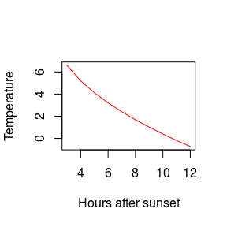

```
#> $x
#>  [1]  3  4  5  6  7  8  9 10 11 12
#>
#> $y
#>  [1]  6.6034223  5.1965137  4.1169548  3.2068445  2.4050213  1.6801177
#>  [7]  1.0135000  0.3930274 -0.1897332 -0.7409219
```

```r
# We plot the temperature trend, we have 12 hours until sunrise
plotTrend(Tmin = ptmin ,t2 = current_temp,n = 12) # in °C degress
```

We can plot an estimated temperature trend during a frost night, calculated using the FAO recomendation.

```r
library(frost)

plotTrend(Tmin = 22.2,t2 = 33.7,n = 15) # in °F degress
```

[output not shown]

```
#> $x
#>  [1]  3  4  5  6  7  8  9 10 11 12 13 14 15
#>
#> $y
#>  [1] -0.8250406 -1.5602865 -2.1244606 -2.6000813 -3.0191115 -3.3979438
#>  [7] -3.7463161 -4.0705731 -4.3751219 -4.6631713 -4.9371438 -5.1989211
#> [13] -5.4500000
```

[figure not shown]

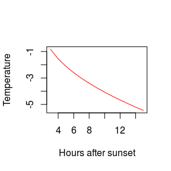

```r
plotTrend(Tmin = -5.45,t2 = 0.95,n = 15) # in °C degress
```

### Empirical formula used in Mendoza

```r
# just an example
dw <- c(-2,-5,2,6,8)
tempMax <- c(10,20,30,25,29)
tmin <- c(-1,-2,3,5,10)
out <- buildMdz(dw,tempMax,tmin)
print(out)
```

```
#> $model
#>
#> Call:
#> lm(formula = tmin ~ ., data = as.data.frame(dd))
#>
#> Coefficients:
#> (Intercept)           dw      tempMax
#>     -0.2365       0.7847       0.0800
#>
#>
#> $k
#> [1] -9.3
#>
#> $kmean
#> [1] -9.3
```

```r
predMdz(dw = -3, tempMax = 15, K=out$k)
```

```
#> [1] 15.3
```